# SSRP: Differential Analysis

Fidan Sadig

### **Script #2 Extras**

```r
#copying all the data from the previous script is too much

#here are the updated lines:

# var_gr <- summary %>%
#   ggplot(aes(x = PC, y = var_explained)) +
#   geom_bar(stat="identity") +
#   theme_minimal()+
#   theme(legend.position = "none")  +

# cum_gr <- summary %>%
#   ggplot(aes(x = PC, y = cumulative_perc)) +
#   geom_bar(stat="identity") +
#    theme_minimal()+
#   theme(legend.position = "none")  +
#   labs(title = "Normalized Gene Expression")
#
#
# ggarrange(var_gr,cum_gr, nrow = 1, ncol = 2)



#does not work, not errors but also nothing is being displayed
#a <- read_chunk ("2_QC.Rmd",from = c(626,662, 699), to = c(635,674, 714) )
```

### **0.0 Introduction**

Note: Okay, I forgot to ask you to save the `mDat` and `eNorm` objects from last time, so I’ve manually saved them within the `data` folder

**I haven’t labelled the code chunks for this script, or added any chunk or figure parameters, or provided any theme and colours - go ahead and do so**

### **1.0 Loading Packages**

```r
# rmarkdown packages
library(knitr)
library(rmarkdown)
library(devtools)
# data wrangling packages
library(tidyverse)
library(reshape2)
library(magrittr)
```

```r
library(stringr)

# data loading packages
library(readxl)
library(openxlsx)
#library(here)

# plotting/table packages
library(arsenal)
library(janitor)
library(kableExtra)
library(egg)
library(RColorBrewer)
library(ggpubr)
# advanced genomic packages
# remotes::install_github("wvictor14/plomics")
library(plomics)

library(BiocManager)
# BiocManager::install("edgeR")
library(edgeR)
library(pheatmap)

# BiocManager::install(c("limma", "edgeR", "DESeq2", "biomaRt", "miRBaseConverter", "multiMiR", "preprocessCore"))
```

### **2.0 Data**

Load in your `eDat`, `eNorm`, `pDat`, and `mDat` RDS objects

```r
eDat <- readRDS(here::here("data", "eDat.RDS"))
pDat <- readRDS(here::here("data", "pDat.RDS"))
eNorm <- readRDS(here::here("data", "eNorm_log2.RDS"))
mDat <- readRDS(here::here("data", "mDat.RDS"))



eNorm_plot <- eNorm %>%
  rownames_to_column("mirs") %>%
  pivot_longer(cols = c(-mirs), names_to = "Case_ID", values_to = "Reads") %>%
  left_join(pDat, by = "Case_ID") %>%
  mutate(Trimester = fct_relevel(Trimester, c("1", "2", "3")))
```

### **3.0 Differential Expression**

Now, when we want to get genes which show differential expression by a variable, we first need to decide which variables to control for ([either a confounder or covariate](https://www.straighthealthcare.com/confounder-covariate.html)) i.e., meaning that knowing that those variables do count towards the variability in expression that we see, we want to ensure that the results that we get are not driven by these other variables

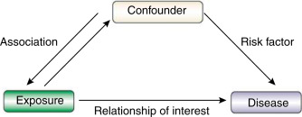

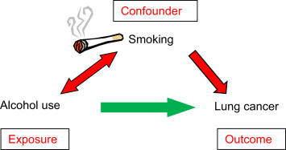

From the `2_QC` script, we determined that the following variables contribute towards the variability in our data:

- Trimester
- flowCell
- RQS
- Processing_time

So, if we want to see the genes differentially expressed by Trimester, then we have to control for the other 3 variables, and so on.

To do our differential expression analysis, we will use a statistical test called as linear regression

To run this test, we first need to make a matrix, called the `model matrix` which includes the main variable by which we want to assess DE by and all the confounders that we are going to use in our model

#### **3.1 Trimester**

```r
tri_mat <- model.matrix(~Trimester + flowCell + RQS + Processing_time, data = pDat)
```

What you’ll see now is all the variables that we want, along with the values for each sample, where 0 represents that variable is not present for the sample, and 1 indicating that it is. The intercept column is the baseline variable by which you’re measuring the variable against - here by default it is Trimester 1

We’re now going to fit the matrix to our normalized gene expression (make sure that the genes are rownames) and then apply an additional method called as Empirical Bayes analysis - which updates the distribution of our results from the linear model based on something called as [prior probability](http://varianceexplained.org/r/empirical_bayes_baseball/), which is the original distribution of our data

```r
# fitting the linear model
tri_fit <- lmFit(eNorm, design = tri_mat)

# Empirical Bayes
tri_efit <- eBayes(tri_fit) #ignore the warning
```

And now, we’re going to pull out the top 10 DE miRNAs, using the `topTable` function setting the following parameters:

- `coef = 1` = that we want trimester 1 as the variable
- `adjust.method = "BH"` = that we want to apply the Benjamini-Hochberg/False Discovery Method (FDR) method of multiple tesing correction
- `p.value <= 0.05` = keep only genes with an adjusted p-value of 0.05 or less
- `sort.by = "logFC"` = sort by highest to lowest log-fold-change

**What is a p-value? How do you decide if something is at a significant p-value or not?** It is a value that can validate hypothesized vs observed data. Usually below 0.05 is considered significant.

**What is fold change?**  
It is a magnitude of expression change

```r
topTable(tri_efit, adjust.method = "BH", coef = 1, p.value = 0.05, sort.by = "logFC")
```

```
##                    logFC  AveExpr         t      P.Value    adj.P.Val         B
## hsa-miR-22-3p   17.50230 16.00000 13.831992 9.606324e-13 1.866247e-10 18.363465
## hsa-miR-516a-5p 16.67615 13.33333 10.417463 2.954432e-10 1.002162e-08 12.441117
## hsa-miR-24-3p   16.10786 14.66667 11.047648 9.357558e-11 3.999420e-09 13.628415
## hsa-miR-517a-3p 15.95276 15.36667  8.085657 3.180460e-08 5.394161e-07  7.621163
## hsa-miR-517b-3p 15.95276 15.36667  8.085657 3.180460e-08 5.394161e-07  7.621163
## hsa-miR-99b-5p  14.78387 15.06667 16.460179 2.375313e-14 1.269011e-11 22.193137
## hsa-miR-27a-3p  14.64855 12.80000 13.287464 2.217892e-12 3.024140e-10 17.497672
## hsa-miR-26b-5p  14.47341 13.00000  9.442890 1.919391e-09 4.825575e-08 10.510755
## hsa-miR-143-3p  14.36760 16.36667 12.856771 4.381751e-12 4.590974e-10 16.793260
## hsa-miR-200c-3p 14.27849 11.83333  8.059749 3.363513e-08 5.615489e-07  7.563671
```

```r
#to get the summary of number of significant and non-significant genes at our multiple testing parameters
decideTests(tri_efit, adjust.method = "BH", p.value = 0.05) %>%
  summary()
```

```
##        (Intercept) Trimester2 Trimester3 flowCellC5JC4ACXX flowCellC6RGTANXX
## Down             1         15         58                 1                 3
## NotSig        1674       2110       2029              2136              2132
## Up             462         12         50                 0                 2
##         RQS Processing_time
## Down      4               0
## NotSig 2132            2135
## Up        1               2
```

```r
# to get all the results, and not just the top 10 - you can also specify the name of the coefficient by looking at the model matrix column names (coef = "Trimester2")
demirs_tri_1 <- topTable(tri_efit, adjust.method = "BH", coef = 1, p.value = 0.05, sort.by = "logFC", n = Inf)
```

What we’ve got now are miRNAs that are DE between Trimester 1 and Trimester 2+3 combined i.e., expressed differently in trimester 1 of the pregnancy in comparison to later on in pregnancy/the rest of the pregnancy (essentially a binary variable question)

We’re now going to make a Volcano Plot which shows us the distribution of our miRNAs by p-value and logFC - we’ll include all the miRNAs, both significant and non

**Make a new column denoting whether a miR is significant or not significant at a p-value <= 0.05 and a logFC of either >=1 or <= -1** - Double check your case_when results, you’re going to have to use multiple arguments to get the exact results from the pval + logFC combinations

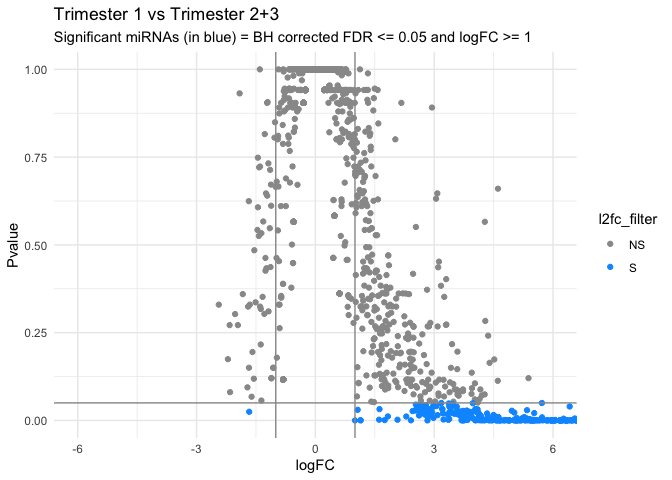

```r
all_tri1 <- topTable(tri_efit, adjust.method = "BH", coef = 1, p.value = 1, sort.by = "logFC", n = Inf)

all_tri1 <- all_tri1 %>%
    mutate(l2fc_filter = case_when(adj.P.Val <=0.05 & logFC >=1  ~ "S",
                                   adj.P.Val  <= 0.05 & logFC <= -1 ~ "S",
                                   adj.P.Val >= 0.05  &    logFC >=1 ~ "NS",
                                   adj.P.Val >= 0.05  & logFC <= -1 ~ "NS",

                                   adj.P.Val >0.05  & between(logFC,-1,1) ~ "NS",
                                   adj.P.Val <0.05 &  between(logFC,-1,1) ~ "NS"

  ))


all_tri1 %>%
  ggplot(aes(x = logFC, y = adj.P.Val, colour = l2fc_filter)) +
  geom_point() +
  coord_cartesian(x = c(-6,6)) +
  geom_vline(xintercept = c(-1, 1), color = "#999999") +
  geom_hline(yintercept = 0.05, color = "#999999") +
  scale_colour_manual(values = c("#999999", "#0099ff")) +
  theme_minimal() +
  labs(x = "logFC", y = "Pvalue", title = "Trimester 1 vs Trimester 2+3", subtitle = "Significant miRNAs (in blue) = BH corrected FDR <= 0.05 and logFC >= 1")
```

So, all our significant DEmiRs at adjusted pval <= 0.05 + logFC of >= 1 are coloured in blue - but that doesn’t look like a volcano plot tho - to get better vizualization, this y-axis of type of plot is converted to -log10 scale (the negative value flips the scale, and the log10 enhances it)

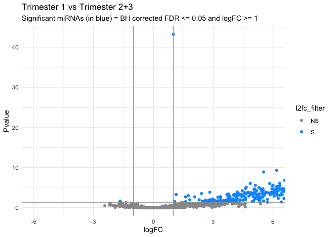

```r
all_tri1 %>%
  ggplot(aes(x = logFC, y = -log10(adj.P.Val), colour = l2fc_filter)) +
  geom_point() +
  coord_cartesian(x = c(-6,6)) +
  geom_vline(xintercept = c(-1, 1), color = "#999999") +
  geom_hline(yintercept = -log10(0.05), color = "#999999") +
  scale_colour_manual(values = c("#999999", "#0099ff")) +
  theme_minimal() +
  labs(x = "logFC", y = "Pvalue", title = "Trimester 1 vs Trimester 2+3", subtitle = "Significant miRNAs (in blue) = BH corrected FDR <= 0.05 and logFC >= 1")
```

**Select the DEmiRNAs for trimester 2 and then trimester 3, and make their respective volcano plots**

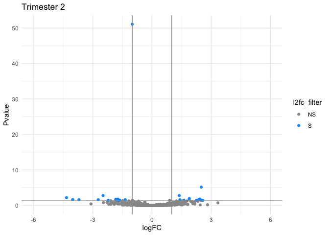

```r
all_tri2 <-  topTable(tri_efit, adjust.method = "BH", coef = 2, p.value = 1, sort.by = "logFC", n = Inf) %>%
  mutate(l2fc_filter = case_when(adj.P.Val <=0.05 & logFC >=1  ~ "S",
                                   adj.P.Val  <= 0.05 & logFC <= -1 ~ "S",
                                   adj.P.Val >= 0.05  &    logFC >=1 ~ "NS",
                                   adj.P.Val >= 0.05  & logFC <= -1 ~ "NS",

                                   adj.P.Val >0.05  & between(logFC,-1,1) ~ "NS",
                                   adj.P.Val <0.05 &  between(logFC,-1,1) ~ "NS"

  ))

all_tri2%>%
  ggplot(aes(x = logFC, y = -log10(adj.P.Val), colour = l2fc_filter)) +
  geom_point() +
  coord_cartesian(x = c(-6,6)) +
  geom_vline(xintercept = c(-1, 1), color = "#999999") +
  geom_hline(yintercept = -log10(0.05), color = "#999999") +
  scale_colour_manual(values = c("#999999", "#0099ff")) +
  theme_minimal() +
  labs(x = "logFC", y = "Pvalue", title = "Trimester 2")
```

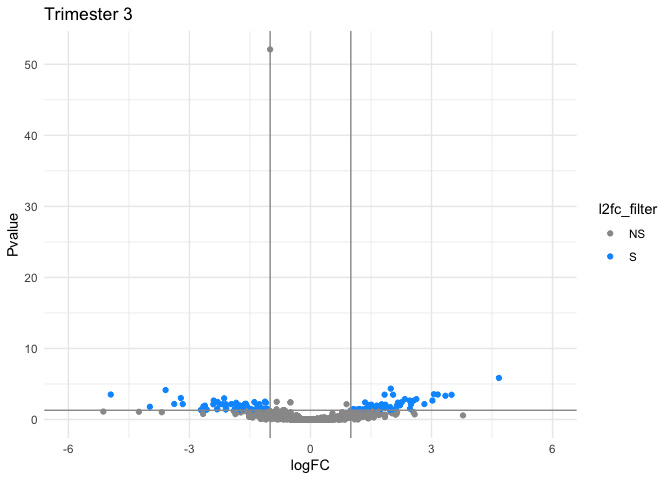

```r
all_tri3 <-topTable(tri_efit, adjust.method = "BH", coef = 3, p.value = 1, sort.by = "logFC", n = Inf) %>%
  mutate(l2fc_filter = case_when(adj.P.Val <=0.05 & logFC >=1  ~ "S",
                                   adj.P.Val  <= 0.05 & logFC <= -1 ~ "S",
                                   adj.P.Val >= 0.05  &    logFC >=1 ~ "NS",
                                   adj.P.Val >= 0.05  & logFC <= -1 ~ "NS",

                                   adj.P.Val >0.05  & between(logFC,-1,1) ~ "NS",
                                   adj.P.Val <0.05 &  between(logFC,-1,1) ~ "NS"

  ))

all_tri3%>%
  ggplot(aes(x = logFC, y = -log10(adj.P.Val), colour = l2fc_filter)) +
  geom_point() +
  coord_cartesian(x = c(-6,6)) +
  geom_vline(xintercept = c(-1, 1), color = "#999999") +
  geom_hline(yintercept = -log10(0.05), color = "#999999") +
  scale_colour_manual(values = c("#999999", "#0099ff")) +
  theme_minimal() +
  labs(x = "logFC", y = "Pvalue", title = "Trimester 3")
```

**Now, do the following:**

- **Filter to only keep the significant miRNAs in all three trimester comparisons**

```r
tri_sig_1 <- all_tri1 %>%
  filter ((adj.P.Val <=0.05 & logFC >=1 ) | (adj.P.Val  <= 0.05 & logFC <= -1))

tri_sig_2 <- all_tri2 %>%
   filter ((adj.P.Val <=0.05 & logFC >=1) |(adj.P.Val  <= 0.05 & logFC <= -1))


tri_sig_3 <- all_tri3 %>%
    filter ((adj.P.Val <=0.05 & logFC >=1 ) |(adj.P.Val  <= 0.05 & logFC <= -1))
```

- **Add a column to each of the dfs denoting the coefficient/trimester for which we selected to get the results**

```r
tri_sig_1 <- tri_sig_1  %>%
  mutate (Trimester = "1")

tri_sig_2 <-tri_sig_2 %>%
   mutate (Trimester = "2")

tri_sig_3 <- tri_sig_3 %>%
   mutate (Trimester = "3")
```

- **Check if there are any common significant miRNAs between the three comparisons**

```r
# common_tri_1 <-merge(tri_sig_1, tri_sig_2, by="row.names")  %>%  # couldn't make it work with inner_join; it automatically creates a column                                                                      names row.names; I need to make it back into rows for the next step
#   rename ("microRNA" = "Row.names")

tri_sig_1 <- tri_sig_1%>%
  rownames_to_column(var="microRNA")
tri_sig_2 <- tri_sig_2 %>%
    rownames_to_column(var="microRNA")
tri_sig_3 <- tri_sig_3 %>%
   rownames_to_column(var="microRNA")

common_tri <- tri_sig_1 %>%
  inner_join(tri_sig_2, by = "microRNA") %>%
   inner_join(tri_sig_3, by = "microRNA")

#the six DEmiRNAs
#hsa-miR-143-3p, hsa-miR-30a-5p, hsa-miR-429    , hsa-miR-503-3p, hsa-miR-195-3p, hsa-miR-377-3p
```

**CHECKPOINT:** You should have:

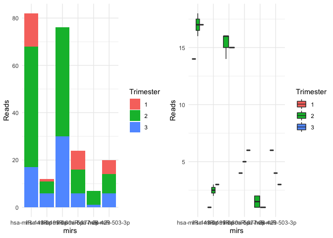

```r
v_1 <- eNorm_plot %>%
  filter (mirs == c("hsa-miR-143-3p", "hsa-miR-30a-5p", "hsa-miR-429","hsa-miR-503-3p","hsa-miR-195-3p","hsa-miR-377-3p")) %>%
  ggplot(aes(x = mirs, y = Reads, fill = Trimester)) +
  geom_bar(stat="identity") +
  theme_minimal()

v_2 <- eNorm_plot %>%
  filter (mirs == c("hsa-miR-143-3p", "hsa-miR-30a-5p", "hsa-miR-429","hsa-miR-503-3p","hsa-miR-195-3p","hsa-miR-377-3p")) %>%
  ggplot(aes(x = mirs, y = Reads, fill = Trimester)) +
  geom_boxplot() +
  theme_minimal()

ggarrange(v_1,v_2, nrow=1, ncol=2) #I feel bar plot looks better
```

```r
#Selected the wrong data frame at the beginning
# common_tri %>%
#   ggplot(aes(x = DEmiRNAs, y = logFC.x, fill = Trimester)) +
#   geom_boxplot() +
#   theme_minimal()
```

**Is there any literature already present depicting a connection between these 6 miRNAs and the placenta? Briefly write down what you find, and link the relevant paper.**

I couldn’t find a paper mentioning all 6 microRNAs and I couldn’t find articles mentioned some of them associated with placenta either. This is what I could find. Note: I need more time to thoroughly do research.

miR-143 are important in the development of macrosomia (https://www.mdpi.com/2073-4409/11/9/1588/htm)

miR-30a-3p was increased significantly in the placenta of women with preeclampsia (https://www.sciencedirect.com/science/article/pii/S0002937817323335?casa_token=9UuEhurHc0YAAAAA:NidBFbKlOpDpQBXzdhDwLXJUjcAOFtncX_jH4bWLzMeYvxhwdbvV2fIOWkA3Tv8u5PNUXJWqWQc)

Clinical sample analysis has revealed that miR-429 expression in preeclamptic placenta is higher than that in normal placenta, (https://www.tandfonline.com/doi/full/10.1080/21655979.2021.1923238)

Hsa-miR-503-5p, a mature miRNA derived from 5’ ends of pre-miR-503, has been proved to regulate cell proliferation, transformation, migration and invasion. (https://content.iospress.com/articles/cancer-biomarkers/cbm170585)

#### **3.1.2 With Contrasts**

Now, this plot doesn’t seem to make much sense, but given that we compared one trimester to the rest of the two *together*, we didn’t select the miRNAs that showed a difference in expression in each trimester - e.g., Trimester 1 compared to Trimester 2+3 is different than Trimester 1 compared to Trimester 2 and Trimester 1 compared to Trimester 3

That’s what we’ll do now then - compare the differences separately by using a separate matrix within our linear model called a contrast matrix. This type of matrix is very useful when you want to compare timepoints or conditions by each of the values within that variable

```r
conMat <- makeContrasts(
  t2_vs_t1 = Trimester2 - Intercept,
  t3_vs_t1 = Trimester3 - Intercept,
  t3_vs_t2 = Trimester3 - Trimester2,
  levels = tri_mat
)
con_fit <- contrasts.fit(tri_fit, conMat) %>%
  eBayes()
topTable(con_fit, adjust.method = "BH", coef = 1, p.value = 0.05, sort.by = "logFC")
```

```
##                     logFC   AveExpr          t      P.Value    adj.P.Val
## hsa-miR-516a-5p -18.36041 13.333333  -8.455572 1.444531e-08 6.157163e-07
## hsa-miR-22-3p   -18.11106 16.000000 -10.551833 2.303209e-10 5.267497e-08
## hsa-miR-9-5p    -17.77951  9.466667  -7.296792 1.819234e-07 5.183604e-06
## hsa-miR-451a    -15.21508 11.000000  -5.122754 3.289114e-05 3.904910e-04
## hsa-miR-200c-3p -15.00102 11.833333  -6.242442 2.121482e-06 3.778006e-05
## hsa-miR-518e-5p -14.82583 14.300000  -9.668130 1.232574e-09 1.013081e-07
## hsa-miR-519b-5p -14.82583 14.300000  -9.668130 1.232574e-09 1.013081e-07
## hsa-miR-519c-5p -14.82583 14.300000  -9.668130 1.232574e-09 1.013081e-07
## hsa-miR-522-5p  -14.82583 14.300000  -9.668130 1.232574e-09 1.013081e-07
## hsa-miR-523-5p  -14.82583 14.300000  -9.668130 1.232574e-09 1.013081e-07
##                          B
## hsa-miR-516a-5p  8.5488496
## hsa-miR-22-3p   12.8127931
## hsa-miR-9-5p     5.9489800
## hsa-miR-451a     0.6604583
## hsa-miR-200c-3p  3.4397170
## hsa-miR-518e-5p 11.0827684
## hsa-miR-519b-5p 11.0827684
## hsa-miR-519c-5p 11.0827684
## hsa-miR-522-5p  11.0827684
## hsa-miR-523-5p  11.0827684
```

```r
decideTests(con_fit, adjust.method = "BH", p.value = 0.05) %>%
  summary()
```

```
##        t2_vs_t1 t3_vs_t1 t3_vs_t2
## Down        383      395       30
## NotSig     1751     1739     2093
## Up            3        3       14
```

**Make dfs of the significant DEmiRNAs as above, check if there are any common DEmiRNAs and plot a boxplot and dotplot by trimester for the common**

```r
t2_t1 <- topTable(con_fit, adjust.method = "BH", coef = 1, p.value = 1, sort.by = "logFC",n = Inf)
t3_t1 <- topTable(con_fit, adjust.method = "BH", coef = 2, p.value = 1, sort.by = "logFC",n = Inf)
t3_t2 <- topTable(con_fit, adjust.method = "BH", coef = 3, p.value = 1, sort.by = "logFC",n = Inf)


sig_t2_t1 <- t2_t1 %>%
   filter ((adj.P.Val <=0.05 & logFC >=1 ) | (adj.P.Val  <= 0.05 & logFC <= -1)) %>%
   rownames_to_column(var = "mirna")


sig_t3_t1 <- t3_t1 %>%
   filter ((adj.P.Val <=0.05 & logFC >=1 ) | (adj.P.Val  <= 0.05 & logFC <= -1)) %>%
   rownames_to_column(var = "mirna")

sig_t3_t2 <- t3_t2 %>%
  filter ((adj.P.Val <=0.05 & logFC >=1 ) | (adj.P.Val  <= 0.05 & logFC <= -1)) %>%
   rownames_to_column(var = "mirna")


common_con_tri <- sig_t2_t1 %>%
  inner_join(sig_t3_t2, by = "mirna" )  %>%
  inner_join(sig_t3_t1, by = "mirna" )

gr_1<- eNorm_plot %>%
  filter(mirs == "hsa-miR-515-5p") %>%
  ggplot(aes(x = mirs, y = Reads, fill = Trimester)) +
  geom_bar(stat="identity") +
  theme_minimal()

gr_2<- eNorm_plot %>%
  filter(mirs == "hsa-miR-515-5p") %>%
  ggplot(aes(x = mirs, y = Reads, fill = Trimester)) +
  geom_boxplot() +
  theme_minimal()

gr_3<- eNorm_plot %>%
  filter(mirs == "hsa-miR-515-5p") %>%
  ggplot(aes(x = mirs, y = Reads, fill = Trimester)) +
  geom_dotplot(binwidth = 0.03, stackgroups = T)+ #some dots were overlapping and dots were too small to be seen so had to add these lines
  ylim(c(0, 3))
```

```
## geom_dotplot called with stackgroups=TRUE and method="dotdensity". You probably want to set binpositions="all"
```

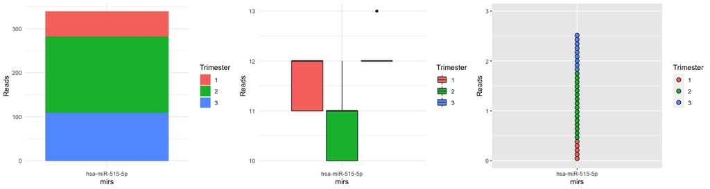

```r
ggarrange(gr_1,gr_2,gr_3, nrow = 1, ncol = 3)
```

**CHECKPOINT:** You should have 1 common DEmiRNA

### 4.0 **Formatting the [Smith et al.,](https://www.tandfonline.com/doi/full/10.1080/15476286.2021.1963105) data**

I’ve downloaded the relevant files from Melanie Smith’s GitHub into the `data/external/` folder, where:

- counts_placenta.txt = raw miRNA counts
- sampleMeta.txt = Meta data
- earlyPlacentamiRNA_SeqProfile = Melanie’s workflow

If you go through her workflow script, you’ll see that she has some initial formatting of the sample names for the `counts_placenta` raw expression data.

**Using relevant object names, read in the Melanie’s data and apply the initial formatting steps that she did.** Can you improve her code? Does it need to be improved, or is it simple and clear enough?

```r
#install.packages("pander")
#install.packages("Rmisc")
#install.packages("ggplotify")


#Data manipulation
library(plyr)
library(reshape2)
library(dplyr)
library(tidyverse)
library(pander)
library(magrittr)

#Differential expression
library(edgeR)
library(limma)
library(Rmisc)
#Visualisation
library(RColorBrewer)
library(ggplot2)
library(ggrepel)
library(ggplotify)
library(pheatmap)
library(ggpubr)
library(xtable)
library(here)
`%notin%` <- Negate(`%in%`)

countsPlacenta <- read.delim(here::here("data/external", "counts_placenta.txt"))
```

```r
#Copy pasted from their workflow

# drop sample Q131 and Q071 - low reads identified in FastQC
countsPlacenta <- dplyr::select(countsPlacenta, -which(names(countsPlacenta) %in% c("Q131_merge_R1", "Q071_merge_R1")))

# remove the "_merge_R1" from the sample name for simplification
names(countsPlacenta) <- sub("_merge_R1","",names(countsPlacenta))

# remove the "Q" prefix from the sample names and replace with PAC
names(countsPlacenta) <- sub("Q","",names(countsPlacenta))

# Create a df of sample names from the counts table, then add PAC prefix and pad to 7 characters
countsPlacentaNames <- data.frame(names(countsPlacenta)) %>%
  mutate(names.countsPlacenta. = paste0("PAC",stringr::str_pad(names.countsPlacenta., width = 4, pad = "0")))

# convert back to a vector and overwrite the colnames in the counts table
countsPlacentaNames <- countsPlacentaNames[,]

# replace the old sample names with the new names (PACXXXX)
names(countsPlacenta) <- countsPlacentaNames

# ensure the columns are ordered by assending sample name
countsPlacenta <- countsPlacenta[,order(colnames(countsPlacenta),decreasing=FALSE)]


# remove multimapped miRNA with identical mature sequences
identicalMature <- c("hsa-miR-199b-3p", "hsa-miR-365b-3p", "hsa-miR-517b-3p", "hsa-miR-518d-5p", "hsa-miR-520c-5p", "hsa-miR-526a", "hsa-miR-518e-5p", "hsa-miR-519b-5p", "hsa-miR-522-5p", "hsa-miR-523-5p", "hsa-miR-519c-5p")

countsPlacenta <- countsPlacenta %>%
  subset(., rownames(.) %notin% identicalMature)
```

**What does `processGroup` signify in this script?**

- `processGroup` = representing the sequencing batch and used for correcting for technical variance

**Recode Melanie’s mDat variable names to match our variable names as much as possible - keep all orginal columns**

Trimester 1 < 13 weeks  
Trimester 2 13 < x < 24 weeks  
Trimester 3 >= 24 weeks

```r
#import the sample metadata
all_samples <- read.delim(here::here("data/external", "sampleMeta.txt"),sep ="\t", header= TRUE)

# drop sample metata for PAC0131 and PAC0071 - failed QC
smith_mDat <- dplyr::filter(all_samples, samplename != c("PAC0131", "PAC0071")) %>%
  mutate (Trimester = case_when (
    gestationalAge <= 13 ~ "Trimester 1",
    between(gestationalAge, 13, 24) ~ "Trimester 2",
    gestationalAge >= 24 ~ "Trimester 24"
  )) %>%
  mutate (Sex = case_when (
    fetalSex == "XY" ~ "Male",
    fetalSex == "XX" ~ "Female"
  ))
```

**Show the distribution of samples by:**

- trimester + sex
- trimester + sex + oxygenation

*Hint*: Add geom_bar(stat = “count”, position = position_dodge2(preserve = “single”))

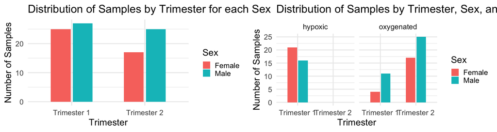

```r
tri_sex <- smith_mDat %>%
  ggplot(aes(x = Trimester, fill = Sex)) +
  geom_bar(stat = "count", width = 0.6,position = position_dodge2(preserve = "single")) +
  theme_minimal(base_size = 20) +
  labs(title = "Distribution of Samples by Trimester for each Sex ", x = "Trimester", y = "Number of Samples")

tri_sex_oxy <- smith_mDat %>%
  ggplot(aes(x = Trimester, fill = Sex)) +
  geom_bar(stat = "count", width = 0.6,position = position_dodge2(preserve = "single")) +
  theme_minimal(base_size = 20) +
  facet_wrap("oxygenation")+
  labs(title = "Distribution of Samples by Trimester, Sex, and Oxygenation", x = "Trimester", y = "Number of Samples")


ggarrange(tri_sex,tri_sex_oxy, nrow=1, ncol= 2)
```

**Filter and Normalize this data as we did for our data**

```r
#removing microRNA with 0 counts

#Copy pasted from script #2

external_Fil_0 <- countsPlacenta %>%
  filter_all(any_vars(. > 0)) %>%
  column_to_rownames(var="PACmirna")

external_Fil_0 %>%
  mutate(Sums = rowSums(.)) %>%
  filter (Sums == 0)
```

```
##                 PAC0006 PAC0007 PAC0008 PAC0009 PAC0010 PAC0011 PAC0012 PAC0013
## hsa-miR-1233-5p       0       0       0       0       0       0       0       0
##                 PAC0014 PAC0015 PAC0016 PAC0017 PAC0018 PAC0020 PAC0021 PAC0022
## hsa-miR-1233-5p       0       0       0       0       0       0       0       0
##                 PAC0023 PAC0024 PAC0025 PAC0026 PAC0027 PAC0029 PAC0030 PAC0031
## hsa-miR-1233-5p       0       0       0       0       0       0       0       0
##                 PAC0032 PAC0033 PAC0034 PAC0035 PAC0036 PAC0037 PAC0038 PAC0039
## hsa-miR-1233-5p       0       0       0       0       0       0       0       0
##                 PAC0040 PAC0041 PAC0042 PAC0043 PAC0044 PAC0045 PAC0046 PAC0047
## hsa-miR-1233-5p       0       0       0       0       0       0       0       0
##                 PAC0048 PAC0049 PAC0050 PAC0051 PAC0052 PAC0053 PAC0054 PAC0055
## hsa-miR-1233-5p       0       0       0       0       0       0       0       0
##                 PAC0056 PAC0057 PAC0058 PAC0059 PAC0060 PAC0062 PAC0063 PAC0064
## hsa-miR-1233-5p       0       0       0       0       0       0       0       0
##                 PAC0065 PAC0069 PAC0070 PAC0072 PAC0074 PAC0075 PAC0076 PAC0077
## hsa-miR-1233-5p       0       0       0       0       0       0       0       0
##                 PAC0078 PAC0083 PAC0084 PAC0086 PAC0087 PAC0088 PAC0091 PAC0093
## hsa-miR-1233-5p       0       0       0       0       0       0       0       0
##                 PAC0097 PAC0098 PAC0099 PAC0100 PAC0102 PAC0103 PAC0105 PAC0107
## hsa-miR-1233-5p       0       0       0       0       0       0       0       0
##                 PAC0108 PAC0109 PAC0111 PAC0114 PAC0117 PAC0118 PAC0120 PAC0122
## hsa-miR-1233-5p       0       0       0       0       0       0       0       0
##                 PAC0124 PAC0127 PAC0129 PAC0134 PAC0139 PAC0140 Sums
## hsa-miR-1233-5p       0       0       0       0       0       0    0
```

```r
 external_Fil_0 %>%
  mutate(Sums = rowSums(.))
```

[output not shown]

[output cut: 14688 more lines]

[output not shown]

```r
 #keep miRNAs with an expression count of 1 or more in 2 or more samples

external_Fil_1_2 <- external_Fil_0 >=1

external_Fil_1_2 <- external_Fil_1_2 %>%
  as.data.frame() %>% #the above function converts the df into a matrix, and there are a few functions we cannot apply to matrices
  mutate(Sum = rowSums(.))

external_Fil_1_2 <- external_Fil_1_2 %>%
  filter(Sum >= 2)

external_Fil_0 <- external_Fil_0 %>%
  rownames_to_column("mirs")

external_Fil <- external_Fil_1_2 %>%
  rownames_to_column("mirs") %>%
  dplyr::select(mirs) %>%
  left_join(external_Fil_0, by = "mirs")

all(countsPlacenta$mirna == rownames(external_Fil_1_2))
```

```
## [1] TRUE
```

```r
#remove duplicates

external_Fil_last <- external_Fil %>%

  mutate(Sum = rowSums(select_if(., is.numeric))) %>%
  # here I'm specifying to select only the numeric columns, because our first column are the miRNA names

  group_by(mirs) %>%
  # grouping by the mature miRNA names

  slice_max(Sum) %>%
  # within the miRNA groups, only keeping the ones which have the highest value in Sum

  dplyr::select(-Sum) %>%
  # removing the Sum and miRNA precursor column (as we have other dfs we can match to find out the precursor if needed)

  distinct(mirs, .keep_all = TRUE)  %>%
  glimpse()
```

```
## Rows: 1,867
## Columns: 95
## Groups: mirs [1,867]
## $ mirs    <chr> "hsa-let-7a-2-3p", "hsa-let-7a-3p", "hsa-let-7a-5p", "hsa-let-…
## $ PAC0006 <dbl> 7, 841, 441286, 112, 305393, 175, 71604, 332, 11967, 66, 28586…
## $ PAC0007 <dbl> 0, 312, 238245, 59, 65199, 31, 21383, 63, 4253, 41, 27050, 0, …
## $ PAC0008 <dbl> 7, 1946, 604541, 448, 301956, 174, 55793, 275, 18411, 166, 430…
## $ PAC0009 <dbl> 2, 370, 116966, 20, 37008, 24, 10190, 55, 2192, 47, 20754, 7, …
## $ PAC0010 <dbl> 0, 127, 28866, 0, 1858, 2, 731, 4, 251, 20, 10700, 4, 8, 8025,…
## $ PAC0011 <dbl> 0, 225, 60119, 4, 5307, 4, 1979, 0, 683, 30, 14822, 6, 14, 162…
## $ PAC0012 <dbl> 0, 97, 32242, 0, 2034, 0, 732, 4, 319, 21, 11031, 2, 3, 8968, …
## $ PAC0013 <dbl> 0, 222, 47400, 2, 2086, 3, 780, 2, 422, 43, 17366, 0, 7, 9147,…
## $ PAC0014 <dbl> 0, 291, 62988, 4, 4395, 5, 1704, 14, 652, 57, 17271, 0, 4, 145…
## $ PAC0015 <dbl> 0, 326, 81506, 0, 3673, 4, 2095, 7, 881, 41, 15963, 0, 15, 197…
## $ PAC0016 <dbl> 0, 211, 54076, 0, 1837, 3, 1243, 4, 421, 25, 10900, 0, 6, 1126…
```

[output cut: 83 more lines]

Not sure how to connect the external_Fil_last and the normalized version of the data

```r
#Copy pasted from script #2

#Normalization
external_Fil <- external_Fil %>%
column_to_rownames(var="mirs")

filteres_mir_names <- as.data.frame(row.names(external_Fil))
samples <- smith_mDat$samplename

# computing normalized counts (between sample normalization of miRNA expression)
norm_counts <- DGEList(counts = external_Fil, samples = samples, genes = filteres_mir_names)
norm_counts <- calcNormFactors(norm_counts, method = "RLE")

# performing within sample normalization of miRNA expression (CPM = Counts per Million = RPM = Reads per Million)
smith_eNorm <- cpm(norm_counts)

# converting to our usual log10 expression
smith_eNorm <- log10(smith_eNorm + 1) #When I use log2 the distribution does not look that well

# converting the expression counts into whole numbers
smith_eNorm <- round(smith_eNorm, digits = 0)

smith_eNorm <- as.data.frame(smith_eNorm)
```

**Plot the density and boxplot distribution of `smith_eNorm`**

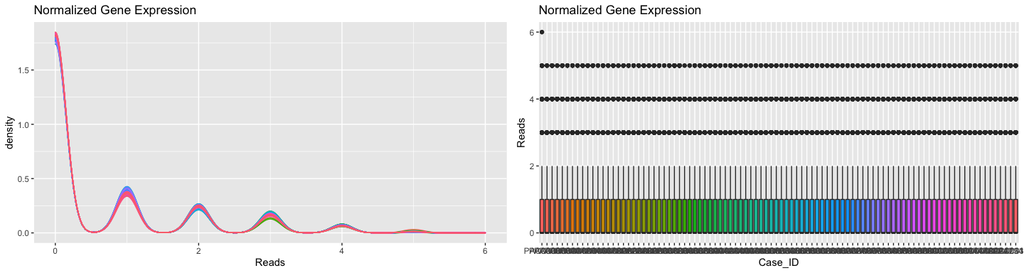

```r
smith_eNorm_plot <- smith_eNorm %>%
  rownames_to_column(var="miRNA") %>%
  pivot_longer(cols = -c("miRNA"),names_to = "Case_ID", values_to = "Reads")

density_smith <- smith_eNorm_plot %>%
  ggplot(aes(x=Reads, colour = Case_ID)) +
  geom_density() +
    theme(legend.position = "none")+
  labs(title = "Normalized Gene Expression")

bxp_smith <- smith_eNorm_plot %>%
  ggplot(aes(x = Case_ID, y = Reads, fill = Case_ID)) +
  geom_boxplot() +
  theme(legend.position = "none") +
  labs(title = "Normalized Gene Expression")


ggarrange(density_smith,bxp_smith, nrow = 1, ncol = 2 )
```

**Save smith_mDat and smith_eNorm as R objects**

```r
saveRDS(smith_eNorm, here::here ("data", "smith_eNorm.RDS"))
saveRDS(smith_mDat, here::here ("data", "smith_mDat.RDS"))
```